# India’s Metropolitan Air: A PM2.5 Comparison Across Five Cities (2022)

Darakhshan Nehal

# Introduction

India’s five largest metropolitan areas — Delhi, Mumbai, Kolkata, Chennai, and Bengaluru — span the Indo-Gangetic Plain, the western and eastern coasts, the Deccan plateau, and the Bay of Bengal. Each city has a distinct pollution profile shaped by topography, industry, traffic, and climate.

This vignette uses the `vayuayan` package to ask a single question across all five cities:

> **How does PM2.5 pollution vary across India’s major metros — seasonally, spatially, and in terms of monitoring coverage?**

We use two independent data sources throughout:

- **WUSTL ACAG V5GL04** — satellite-derived PM2.5 at ~1 km resolution
- **CPCB CAAQMS** — ground-level monitoring station readings

The analysis follows a deliberate narrative arc:

1. **When** does pollution peak in each city? *(seasonal trends)*
2. **How variable** is pollution day-to-day within each city? *(SD ribbons)*
3. **How much** does each city pollute annually? *(cross-city ranking)*
4. **Where** within each city is pollution worst? *(spatial heatmaps)*
5. **Are cities well monitored** relative to their pollution burden? *(station coverage)*

# Data & Methods

## Satellite Data

Monthly PM2.5 estimates from WUSTL ACAG V5GL04 (~1 km resolution, 1998–2022). Files are read using a fast bounding-box subsetting approach that avoids loading the full 121 MB global array.

## Ground Data

City-level daily PM2.5 downloaded from the CPCB data repository using `cpcb_download_city_data()`. Monthly means are computed from daily readings.

## Cities

[output not shown]

## Comparison Note

Ground readings are consistently higher than satellite estimates due to point-source siting bias. All comparisons within this vignette use the same methodology across cities, making relative comparisons valid even if absolute values differ between sources.

# Setup

```r
if (!require("pacman", quietly = TRUE)) {
  install.packages("pacman", repos = "https://cloud.r-project.org")
}

pacman::p_load(
  vayuayan,
  tidyverse,
  purrr,
  terra,
  sf,
  tidyterra,
  ncdf4,
  khroma,
  scales,
  patchwork,
  ggrepel,
  geodata,
  kableExtra  # formatted tables
)
```

```r
# Absolute path — works both interactively and when knitting
vignettes_dir <- "/NAS/darakshann/vayuayanR/vignettes"

dirs <- c("data/metro", "figures/metro")
for (d in dirs) dir.create(file.path(vignettes_dir, d),
                            recursive = TRUE, showWarnings = FALSE)

data_path <- function(f) file.path(vignettes_dir, "data/metro", f)
fig_path  <- function(f) file.path(vignettes_dir, "figures/metro", f)
```

## City Configuration

```r
cities <- list(
  Delhi     = list(name = "Delhi",     color = "#c0392b"),
  Mumbai    = list(name = "Mumbai",    color = "#2980b9"),
  Kolkata   = list(name = "Kolkata",   color = "#8e44ad"),
  Chennai   = list(name = "Chennai",   color = "#27ae60"),
  Bengaluru = list(name = "Bengaluru", color = "#e67e22")
)

city_names  <- names(cities)
city_colors <- setNames(sapply(cities, `[[`, "color"), city_names)

# Extended 12-city palette for scatter plot
extra_colors <- c(
  Surat     = "#e91e63",
  Kanpur    = "#9c27b0",
  Jaipur    = "#00bcd4",
  Lucknow   = "#3f51b5",
  Pune      = "#ff9800",
  Ahmedabad = "#cddc39",
  Hyderabad = "#ff5722"
)
all_colors   <- c(city_colors, extra_colors)
extra_cities <- names(extra_colors)

city_download_names <- list(
  Delhi = "Delhi", Mumbai = "Mumbai", Kolkata = "Kolkata",
  Chennai = "Chennai", Bengaluru = "Bengaluru"
)

shape_files <- list(
  Delhi     = "/NAS/darakshann/geojson/delhi_gadm.geojson",
  Mumbai    = "/NAS/darakshann/geojson/mumbai_v4.geojson",
  Kolkata   = "/NAS/darakshann/geojson/kolkata.geojson",
  Chennai   = "/NAS/darakshann/geojson/chennai.geojson",
  Bengaluru = "/NAS/darakshann/geojson/bengaluru.geojson"
)
```

## Helper Functions

```r
read_v5gl04_fast <- function(nc_path, shape) {
  bbox    <- sf::st_bbox(shape)
  nc      <- ncdf4::nc_open(nc_path)
  lons    <- ncdf4::ncvar_get(nc, "lon")
  lats    <- ncdf4::ncvar_get(nc, "lat")
  lon_idx <- which(lons >= bbox["xmin"] & lons <= bbox["xmax"])
  lat_idx <- which(lats >= bbox["ymin"] & lats <= bbox["ymax"])
  data    <- ncdf4::ncvar_get(
    nc, "GWRPM25",
    start = c(min(lon_idx), min(lat_idx)),
    count = c(length(lon_idx), length(lat_idx))
  )
  ncdf4::nc_close(nc)
  mean(data, na.rm = TRUE)
}

load_v5gl04_rast <- function(year, month, shape) {
  nc_path <- sprintf(
    "/NAS/climatehealth/WUSTL_PM2.5/V5GL04/Global/Monthly/V5GL04.HybridPM25.Global.%04d%02d-%04d%02d.nc",
    year, month, year, month
  )
  bbox    <- sf::st_bbox(shape)
  nc      <- ncdf4::nc_open(nc_path)
  lons    <- ncdf4::ncvar_get(nc, "lon")
  lats    <- ncdf4::ncvar_get(nc, "lat")
  lon_idx <- which(lons >= bbox["xmin"] & lons <= bbox["xmax"])
  lat_idx <- which(lats >= bbox["ymin"] & lats <= bbox["ymax"])
  data    <- ncdf4::ncvar_get(
    nc, "GWRPM25",
    start = c(min(lon_idx), min(lat_idx)),
    count = c(length(lon_idx), length(lat_idx))
  )
  ncdf4::nc_close(nc)
  r <- terra::rast(
    nrows = length(lat_idx), ncols = length(lon_idx),
    xmin  = min(lons[lon_idx]), xmax = max(lons[lon_idx]),
    ymin  = min(lats[lat_idx]), ymax = max(lats[lat_idx]),
    crs   = "EPSG:4326"
  )
  terra::values(r) <- t(data)[nrow(t(data)):1, ]
  r
}
```

# Results

## 1. When Does Pollution Peak? Seasonal Trends

### Ground Data: City-Level Monthly Means

```r
city_files <- list(
  Delhi     = data_path("delhi_aqi_2022.csv"),
  Mumbai    = data_path("mumbai_aqi_2022.csv"),
  Kolkata   = data_path("kolkata_aqi_2022.csv"),
  Chennai   = data_path("chennai_aqi_2022.csv"),
  Bengaluru = data_path("bengaluru_aqi_2022.csv")
)

for (city in city_names) {
  if (!file.exists(city_files[[city]])) {
    cpcb_download_city_data(
      city          = city_download_names[[city]],
      year          = 2022,
      save_location = city_files[[city]]
    )
  }
}

ground_monthly <- map_dfr(city_names, function(city) {
  df      <- read.csv(city_files[[city]])
  day_col <- names(df)[1]
  df %>%
    pivot_longer(cols = -all_of(day_col),
                 names_to = "Month_Name", values_to = "pm25") %>%
    mutate(month = match(Month_Name, month.name)) %>%
    filter(!is.na(pm25), !is.na(month)) %>%
    group_by(month) %>%
    summarise(ground_pm25 = mean(pm25, na.rm = TRUE), .groups = "drop") %>%
    mutate(city = city)
})
```

### Satellite Data: Monthly Spatial Means

```r
city_shapes <- map(city_names, function(city) {
  sf::st_read(shape_files[[city]], quiet = TRUE) %>%
    sf::st_make_valid() %>%
    sf::st_union()
})
names(city_shapes) <- city_names

sat_monthly <- map_dfr(city_names, function(city) {
  shape <- city_shapes[[city]]
  map_dfr(1:12, function(m) {
    nc_file <- sprintf(
      "/NAS/climatehealth/WUSTL_PM2.5/V5GL04/Global/Monthly/V5GL04.HybridPM25.Global.2022%02d-2022%02d.nc",
      m, m
    )
    tibble(city = city, month = m,
           sat_pm25 = read_v5gl04_fast(nc_file, shape))
  })
})

seasonal_combined <- ground_monthly %>%
  left_join(sat_monthly, by = c("city", "month"))
```

### Seasonal Line Chart

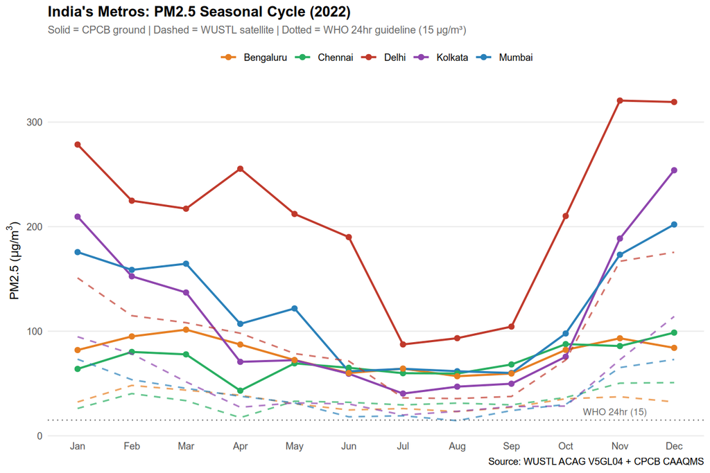

```r
ggplot(seasonal_combined, aes(x = month, color = city)) +
  geom_line(aes(y = ground_pm25), linewidth = 0.9) +
  geom_point(aes(y = ground_pm25), size = 2) +
  geom_line(aes(y = sat_pm25), linewidth = 0.7, linetype = "dashed", alpha = 0.7) +
  geom_hline(yintercept = 15, linetype = "dotted",
             color = "grey40", linewidth = 0.5) +
  annotate("text", x = 11.5, y = 23,
           label = "WHO 24hr (15)", size = 3, color = "grey40", hjust = 1) +
  scale_x_continuous(breaks = 1:12, labels = month.abb) +
  scale_color_manual(values = city_colors, name = NULL) +
  labs(
    title    = "India's Metros: PM2.5 Seasonal Cycle (2022)",
    subtitle = "Solid = CPCB ground | Dashed = WUSTL satellite | Dotted = WHO 24hr guideline (15 µg/m³)",
    y        = expression(paste("PM2.5 (", mu, "g/m"^3, ")")),
    x        = NULL,
    caption  = "Source: WUSTL ACAG V5GL04 + CPCB CAAQMS"
  ) +
  theme_minimal(base_size = 11) +
  theme(
    text               = element_text(family = "Arial"),
    panel.grid.minor   = element_blank(),
    panel.grid.major.x = element_blank(),
    legend.position    = "top",
    plot.title         = element_text(face = "bold"),
    plot.subtitle      = element_text(size = 9.5, color = "grey40")
  )
```

```r
ggsave(fig_path("fig1_metro_seasonal_comparison.png"), width = 10, height = 7, dpi = 300)
```

### 1b. How Variable Is Pollution Day-to-Day?

The seasonal line chart shows monthly *means* — but means hide the day-to-day swings that residents actually experience. A city with a high mean and wide variability is more unpredictable and harder to plan around than one with a steady moderate level. The ribbon below shows ±1 standard deviation around each monthly mean, computed from daily readings.

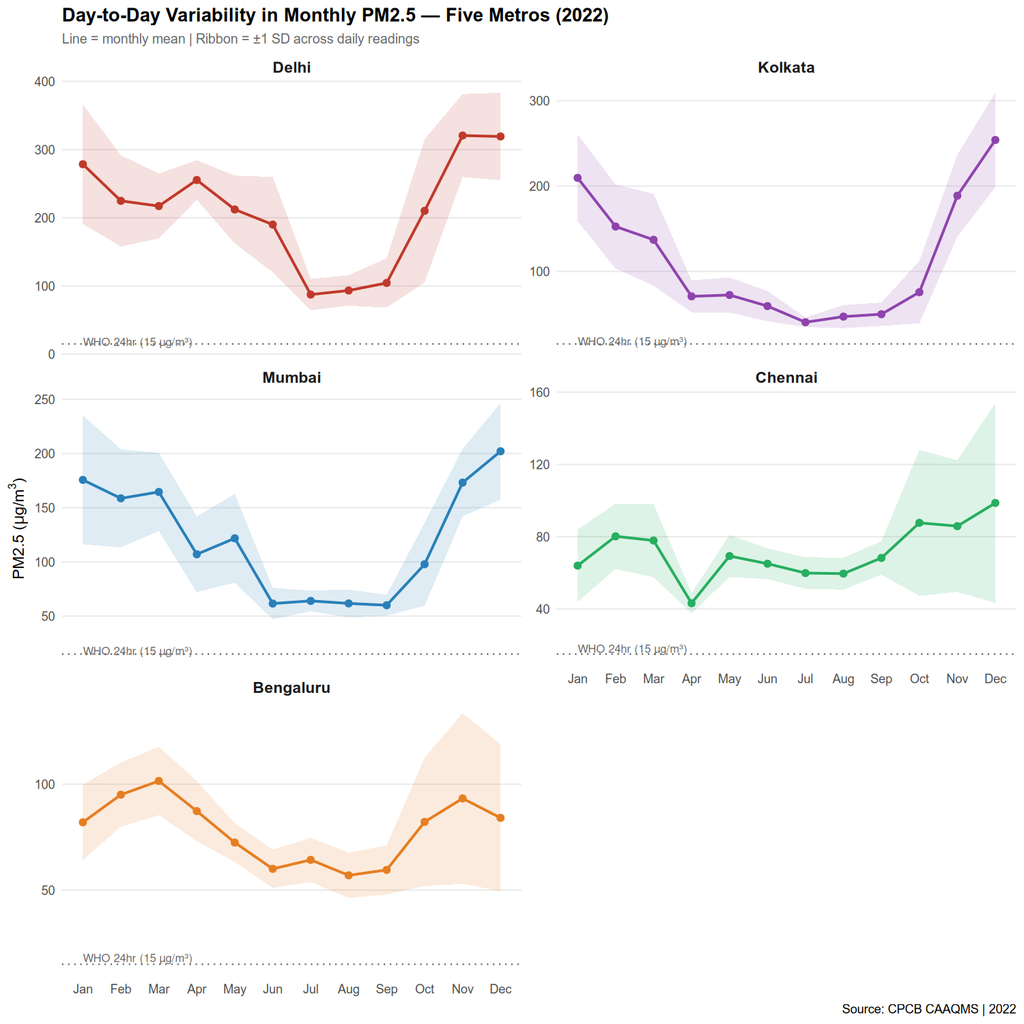

Day-to-day variability in monthly PM2.5 across five metros, 2022. Line = monthly mean. Ribbon = ±1 SD across daily readings. Free Y-axis per city — Delhi’s winter ribbon is enormous, reflecting extreme pollution events layered on top of an already high baseline.

```r
# Compute monthly mean + SD — reuses city_files already loaded above
ground_monthly_sd <- map_dfr(city_names, function(city) {
  df      <- read.csv(city_files[[city]])
  day_col <- names(df)[1]
  df %>%
    pivot_longer(cols     = -all_of(day_col),
                 names_to  = "Month_Name",
                 values_to = "pm25") %>%
    mutate(month = match(Month_Name, month.name)) %>%
    filter(!is.na(pm25), !is.na(month)) %>%
    group_by(month) %>%
    summarise(
      ground_pm25 = mean(pm25, na.rm = TRUE),
      ground_sd   = sd(pm25,   na.rm = TRUE),
      .groups     = "drop"
    ) %>%
    mutate(city = city)
}) %>%
  # Order facets by pollution level — most polluted first
  mutate(city = factor(city,
                       levels = c("Delhi", "Kolkata", "Mumbai",
                                  "Chennai", "Bengaluru")))

ggplot(ground_monthly_sd,
       aes(x = month, color = city, fill = city)) +
  geom_ribbon(
    aes(ymin = ground_pm25 - ground_sd,
        ymax = ground_pm25 + ground_sd),
    alpha = 0.15, color = NA
  ) +
  geom_line(aes(y = ground_pm25), linewidth = 0.9) +
  geom_point(aes(y = ground_pm25), size = 2) +
  geom_hline(yintercept = 15, linetype = "dotted",
             color = "grey40", linewidth = 0.5) +
  annotate("text", x = 1, y = 18,
           label = "WHO 24hr (15 µg/m³)",
           size = 2.8, color = "grey40", hjust = 0) +
  scale_x_continuous(breaks = 1:12, labels = month.abb) +
  scale_color_manual(values = city_colors, guide = "none") +
  scale_fill_manual(values  = city_colors, guide = "none") +
  facet_wrap(~ city, ncol = 2, scales = "free_y") +
  labs(
    title    = "Day-to-Day Variability in Monthly PM2.5 — Five Metros (2022)",
    subtitle = "Line = monthly mean | Ribbon = ±1 SD across daily readings",
    y        = expression(paste("PM2.5 (", mu, "g/m"^3, ")")),
    x        = NULL,
    caption  = "Source: CPCB CAAQMS | 2022"
  ) +
  theme_minimal(base_size = 11) +
  theme(
    text               = element_text(family = "Arial"),
    panel.grid.minor   = element_blank(),
    panel.grid.major.x = element_blank(),
    strip.text         = element_text(face = "bold", size = 11),
    legend.position    = "none",
    plot.title         = element_text(face = "bold"),
    plot.subtitle      = element_text(size = 9.5, color = "grey40")
  )
```

```r
ggsave(fig_path("fig1b_metro_seasonal_variability.png"),
       width = 10, height = 10, dpi = 300)
```

> **Key finding:** Delhi’s winter ribbon is dramatically wider than any other city — not just the mean but the day-to-day swings are extreme. A Delhi resident experiences more pollution variability in a single winter month than a Bengaluru resident experiences across the entire year.

## 2. How Much Does Each City Pollute? Cross-City Ranking

Before looking at spatial patterns, we establish how cities compare in absolute terms. This gives the frame of reference needed to interpret the heatmaps that follow.

```r
annual_sat <- sat_monthly %>%
  group_by(city) %>%
  summarise(annual_sat_pm25 = mean(sat_pm25, na.rm = TRUE), .groups = "drop")

annual_ground <- ground_monthly %>%
  group_by(city) %>%
  summarise(annual_ground_pm25 = mean(ground_pm25, na.rm = TRUE), .groups = "drop")

winter_ground <- ground_monthly %>%
  filter(month %in% c(1, 10, 11, 12)) %>%
  group_by(city) %>%
  summarise(winter_ground_pm25 = mean(ground_pm25, na.rm = TRUE), .groups = "drop")

who_exceedance <- map_dfr(city_names, function(city) {
  df      <- read.csv(city_files[[city]])
  day_col <- names(df)[1]
  df %>%
    pivot_longer(cols = -all_of(day_col),
                 names_to = "Month_Name", values_to = "pm25") %>%
    filter(!is.na(pm25)) %>%
    summarise(
      city            = city,
      who_exceed_days = sum(pm25 > 15, na.rm = TRUE),
      total_days      = sum(!is.na(pm25))
    )
})

city_areas <- map_dfr(city_names, function(city) {
  shape <- sf::st_read(shape_files[[city]], quiet = TRUE) %>%
    sf::st_make_valid() %>%
    sf::st_union() %>%
    sf::st_transform(3857)
  tibble(city = city, area_km2 = as.numeric(sf::st_area(shape)) / 1e6)
})

station_data <- map_dfr(city_names, function(city) {
  stations <- cpcb_get_station_list(city_download_names[[city]])
  tibble(city = city, n_stations = nrow(stations))
})

city_summary <- station_data %>%
  left_join(city_areas,     by = "city") %>%
  left_join(annual_sat,     by = "city") %>%
  left_join(annual_ground,  by = "city") %>%
  left_join(winter_ground,  by = "city") %>%
  left_join(who_exceedance, by = "city") %>%
  mutate(
    stations_per_100km2 = round(n_stations / area_km2 * 100, 2),
    who_exceed_pct      = round(who_exceed_days / total_days * 100, 1)
  )
```

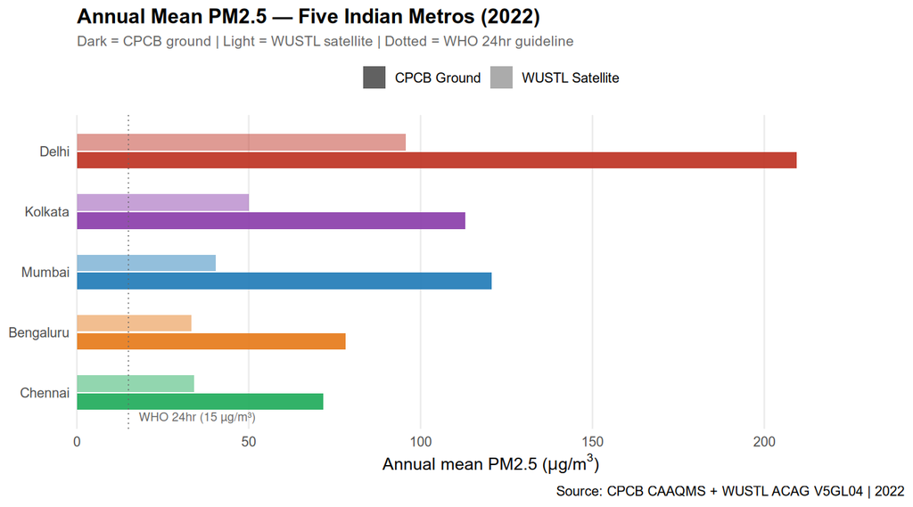

Annual mean PM2.5 ranked across five Indian metros, 2022. All cities exceed the WHO 24-hour guideline of 15 µg/m³. Delhi’s annual mean is multiple times the WHO limit.

```r
rankings <- city_summary %>%
  arrange(desc(annual_ground_pm25)) %>%
  mutate(
    annual_ground_pm25 = round(annual_ground_pm25, 1),
    annual_sat_pm25    = round(annual_sat_pm25, 1)
  )

# Both ground and satellite side by side
rankings_long <- rankings %>%
  select(city, annual_ground_pm25, annual_sat_pm25) %>%
  pivot_longer(cols = c(annual_ground_pm25, annual_sat_pm25),
               names_to = "source", values_to = "pm25") %>%
  mutate(source = recode(source,
    "annual_ground_pm25" = "CPCB Ground",
    "annual_sat_pm25"    = "WUSTL Satellite"
  ))

ggplot(rankings_long,
       aes(x = reorder(city, pm25), y = pm25,
           fill = city, alpha = source)) +
  geom_col(position = position_dodge(width = 0.6), width = 0.55) +
  geom_hline(yintercept = 15, linetype = "dotted",
             color = "grey40", linewidth = 0.4) +
  annotate("text", x = 0.6, y = 18,
           label = "WHO 24hr (15 µg/m³)", size = 3,
           color = "grey40", hjust = 0) +
  coord_flip(clip = "off") +
  scale_fill_manual(values = city_colors, guide = "none") +
  scale_alpha_manual(values = c("CPCB Ground" = 0.95, "WUSTL Satellite" = 0.5),
                     name = NULL) +
  scale_y_continuous(expand = expansion(mult = c(0, 0.15))) +
  labs(
    title    = "Annual Mean PM2.5 — Five Indian Metros (2022)",
    subtitle = "Dark = CPCB ground | Light = WUSTL satellite | Dotted = WHO 24hr guideline",
    x        = NULL,
    y        = expression(paste("Annual mean PM2.5 (", mu, "g/m"^3, ")")),
    caption  = "Source: CPCB CAAQMS + WUSTL ACAG V5GL04 | 2022"
  ) +
  theme_minimal(base_size = 12) +
  theme(
    text               = element_text(family = "Arial"),
    panel.grid.minor   = element_blank(),
    panel.grid.major.y = element_blank(),
    plot.title         = element_text(face = "bold"),
    plot.subtitle      = element_text(size = 10, color = "grey40"),
    legend.position    = "top"
  )
```

```r
ggsave(fig_path("fig2_metro_annual_ranking.png"), width = 10, height = 5, dpi = 300)
```

## 3. Where Is Pollution Worst? Spatial Heatmaps

Now that we know *how much* each city pollutes, we look at *where* within each city the pollution is concentrated. Cities are grouped by geography — the Indo-Gangetic Plain cities (Delhi, Kolkata, Kanpur) share a common pollution driver: the IGP trap. The coastal and southern cities (Mumbai, Chennai, Bengaluru) form a contrasting group. Each city uses its **own independent colour scale** to reveal internal spatial structure clearly.

```r
# Add Kanpur to shape files for IGP group
igp_shape_files <- list(
  Delhi   = "/NAS/darakshann/geojson/delhi_gadm.geojson",
  Kolkata = "/NAS/darakshann/geojson/kolkata.geojson",
  Kanpur  = NULL  # from GADM
)

coastal_shape_files <- list(
  Mumbai    = "/NAS/darakshann/geojson/mumbai_v4.geojson",
  Chennai   = "/NAS/darakshann/geojson/chennai.geojson",
  Bengaluru = "/NAS/darakshann/geojson/bengaluru.geojson"
)

# Kanpur shape from GADM
if (!exists("india_sf")) {
  india_dist <- geodata::gadm("IND", level = 2, path = data_path(""))
  india_sf   <- sf::st_as_sf(india_dist)
}
kanpur_shape <- india_sf %>%
  filter(NAME_2 == "Kanpur Nagar") %>%
  sf::st_make_valid() %>%
  sf::st_union()

# Build all 6 shapes
heatmap_shapes <- list(
  Delhi     = sf::st_read(igp_shape_files$Delhi,         quiet = TRUE) %>% sf::st_make_valid() %>% sf::st_union(),
  Kolkata   = sf::st_read(igp_shape_files$Kolkata,       quiet = TRUE) %>% sf::st_make_valid() %>% sf::st_union(),
  Kanpur    = kanpur_shape,
  Mumbai    = sf::st_read(coastal_shape_files$Mumbai,    quiet = TRUE) %>% sf::st_make_valid() %>% sf::st_union(),
  Chennai   = sf::st_read(coastal_shape_files$Chennai,   quiet = TRUE) %>% sf::st_make_valid() %>% sf::st_union(),
  Bengaluru = sf::st_read(coastal_shape_files$Bengaluru, quiet = TRUE) %>% sf::st_make_valid() %>% sf::st_union()
)

# Load and mask November rasters for all 6 cities
heatmap_cities <- names(heatmap_shapes)
nov_rasters <- map(heatmap_cities, function(city) {
  r <- load_v5gl04_rast(2022, 11, heatmap_shapes[[city]])
  terra::mask(r, terra::vect(heatmap_shapes[[city]]))
})
names(nov_rasters) <- heatmap_cities
```

```r
# Helper to build one heatmap panel
make_heatmap <- function(city, label_color = "grey20") {
  r        <- nov_rasters[[city]]
  boundary <- heatmap_shapes[[city]]
  vals      <- terra::values(r, na.rm = TRUE)
  city_min  <- floor(quantile(vals, 0.02))
  city_max  <- ceiling(quantile(vals, 0.98))
  city_mean <- round(mean(vals), 1)

  ggplot() +
    geom_spatraster(data = r) +
    geom_sf(data = boundary, fill = NA,
            color = label_color, linewidth = 0.5) +
    scale_fill_distiller(
      palette   = "YlOrRd",
      direction = 1,
      limits    = c(city_min, city_max),
      oob       = scales::squish,
      na.value  = NA,
      name      = expression(paste(mu, "g/m"^3))
    ) +
    labs(
      title    = city,
      subtitle = paste0("Nov mean: ", city_mean, " µg/m³")
    ) +
    xlab(NULL) + ylab(NULL) +
    theme_minimal(base_size = 10) +
    theme(
      text              = element_text(family = "Arial"),
      panel.grid        = element_blank(),
      legend.position   = "right",
      legend.key.width  = unit(0.4, "lines"),
      legend.key.height = unit(3,   "lines"),
      legend.text       = element_text(size = 7),
      plot.title        = element_text(face = "bold", hjust = 0.5, size = 11),
      plot.subtitle     = element_text(hjust = 0.5,  size = 9, color = "grey40")
    )
}
```

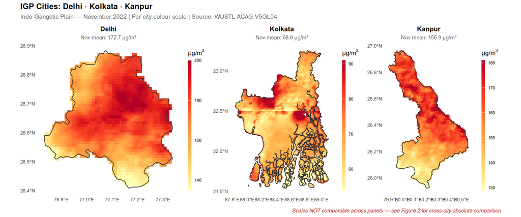

November 2022 PM2.5 — Indo-Gangetic Plain cities (Delhi, Kolkata, Kanpur). All three sit in the IGP pollution trap. Each city uses its own colour scale. For absolute values see Figure 2.

```r
igp_plots <- map(c("Delhi", "Kolkata", "Kanpur"), make_heatmap)

wrap_plots(igp_plots, ncol = 3) +
  plot_annotation(
    title    = "IGP Cities: Delhi · Kolkata · Kanpur",
    subtitle = "Indo-Gangetic Plain — November 2022 | Per-city colour scale | Source: WUSTL ACAG V5GL04",
    caption  = "Scales NOT comparable across panels — see Figure 2 for cross-city absolute comparison",
    theme    = theme(
      plot.title    = element_text(face = "bold", size = 13),
      plot.subtitle = element_text(size = 10, color = "grey40"),
      plot.caption  = element_text(size = 9,  color = "firebrick", face = "italic")
    )
  )
```

```r
ggsave(fig_path("fig3a_heatmaps_igp.png"), width = 13, height = 6, dpi = 300)
```

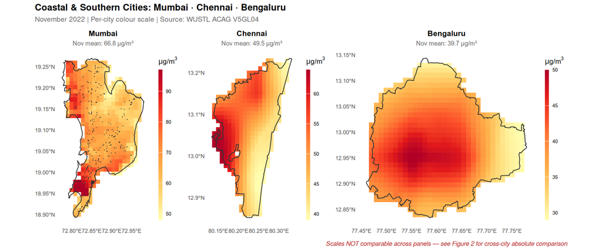

November 2022 PM2.5 — Coastal and southern cities (Mumbai, Chennai, Bengaluru). Sea breezes and elevation give these cities structurally lower pollution, but spatial gradients reveal industrial and traffic hotspots.

```r
coastal_plots <- map(c("Mumbai", "Chennai", "Bengaluru"), make_heatmap)

wrap_plots(coastal_plots, ncol = 3) +
  plot_annotation(
    title    = "Coastal & Southern Cities: Mumbai · Chennai · Bengaluru",
    subtitle = "November 2022 | Per-city colour scale | Source: WUSTL ACAG V5GL04",
    caption  = "Scales NOT comparable across panels — see Figure 2 for cross-city absolute comparison",
    theme    = theme(
      plot.title    = element_text(face = "bold", size = 13),
      plot.subtitle = element_text(size = 10, color = "grey40"),
      plot.caption  = element_text(size = 9,  color = "firebrick", face = "italic")
    )
  )
```

```r
ggsave(fig_path("fig3b_heatmaps_coastal.png"), width = 13, height = 6, dpi = 300)
```

## 4. Are Cities Well Monitored? Station Coverage

A city can have many stations and still be poorly monitored if they are all clustered in one zone. This section asks: across 12 Indian cities, does monitoring investment match pollution burden?

```r
extra_city_files <- list(
  Surat     = data_path("surat_aqi_2022.csv"),
  Kanpur    = data_path("kanpur_aqi_2022.csv"),
  Jaipur    = data_path("jaipur_aqi_2022.csv"),
  Lucknow   = data_path("lucknow_aqi_2022.csv"),
  Pune      = data_path("pune_aqi_2022.csv"),
  Ahmedabad = data_path("ahmedabad_aqi_2022.csv"),
  Hyderabad = data_path("hyderabad_aqi_2022.csv")
)

for (city in extra_cities) {
  if (!file.exists(extra_city_files[[city]])) {
    cpcb_download_city_data(
      city          = city,
      year          = 2022,
      save_location = extra_city_files[[city]]
    )
  }
}

extra_ground <- map_dfr(extra_cities, function(city) {
  df      <- read.csv(extra_city_files[[city]])
  day_col <- names(df)[1]
  df %>%
    pivot_longer(cols = -all_of(day_col),
                 names_to = "Month_Name", values_to = "pm25") %>%
    mutate(month = match(Month_Name, month.name)) %>%
    filter(!is.na(pm25), !is.na(month)) %>%
    summarise(annual_ground_pm25 = mean(pm25, na.rm = TRUE)) %>%
    mutate(city = city)
})

# GADM district name mapping
extra_city_gadm <- list(
  Surat     = "Surat",
  Kanpur    = "Kanpur Nagar",
  Jaipur    = "Jaipur",
  Lucknow   = "Lucknow",
  Pune      = "Pune",
  Ahmedabad = "Ahmadabad",
  Hyderabad = "Hyderabad"
)

if (!exists("india_sf")) {
  india_dist <- geodata::gadm("IND", level = 2, path = data_path(""))
  india_sf   <- sf::st_as_sf(india_dist)
}

extra_areas <- map_dfr(extra_cities, function(city) {
  gadm_name <- extra_city_gadm[[city]]
  shape <- india_sf %>%
    filter(NAME_2 == gadm_name) %>%
    sf::st_make_valid() %>%
    sf::st_union() %>%
    sf::st_transform(3857)
  tibble(city = city, area_km2 = as.numeric(sf::st_area(shape)) / 1e6)
})

# Hyderabad: combine with Ranga Reddy for full GHMC metro area
hyderabad_area <- india_sf %>%
  filter(NAME_1 == "Telangana",
         NAME_2 %in% c("Hyderabad", "Ranga Reddy")) %>%
  sf::st_make_valid() %>%
  sf::st_union() %>%
  sf::st_transform(3857) %>%
  sf::st_area() %>%
  as.numeric() / 1e6

extra_areas <- extra_areas %>%
  mutate(area_km2 = if_else(city == "Hyderabad", hyderabad_area, area_km2))

extra_stations <- map_dfr(extra_cities, function(city) {
  tibble(city = city, n_stations = nrow(cpcb_get_station_list(city)))
})

extra_summary <- extra_stations %>%
  left_join(extra_areas,  by = "city") %>%
  left_join(extra_ground, by = "city") %>%
  mutate(stations_per_100km2 = round(n_stations / area_km2 * 100, 2))

all_city_summary <- bind_rows(
  city_summary %>% select(city, n_stations, area_km2,
                           annual_ground_pm25, stations_per_100km2),
  extra_summary
)

write.csv(all_city_summary, data_path("all_city_summary.csv"), row.names = FALSE)
```

```r
# Table ranked by annual PM2.5 — most polluted first
tbl_data <- all_city_summary %>%
  arrange(desc(annual_ground_pm25)) %>%
  mutate(
    area_km2            = round(area_km2, 0),
    annual_ground_pm25  = round(annual_ground_pm25, 1),
    stations_per_100km2 = round(stations_per_100km2, 3)
  ) %>%
  select(
    City                   = city,
    `Stations`             = n_stations,
    `Area (km²)`           = area_km2,
    `Annual PM2.5 (µg/m³)` = annual_ground_pm25,
    `Stations per 100 km²` = stations_per_100km2
  )

tbl_data %>%
  knitr::kable(
    caption = "Table 1: CPCB monitoring station density across 12 Indian cities (2022). Cities ranked by annual mean PM2.5. Red values in the last column indicate near-zero station density (<0.05 per 100 km²) — the most under-monitored cities relative to their geographic extent.",
    align   = c("l", "r", "r", "r", "r"),
    format  = "html"
  ) %>%
  kableExtra::kable_styling(
    bootstrap_options = c("striped", "hover", "condensed"),
    full_width        = FALSE,
    position          = "center"
  ) %>%
  kableExtra::column_spec(
    5,
    bold  = TRUE,
    color = ifelse(tbl_data$`Stations per 100 km²` < 0.05, "red", "black")
  )
```

Table 1: CPCB monitoring station density across 12 Indian cities (2022). Cities ranked by annual mean PM2.5. Red values in the last column indicate near-zero station density (<0.05 per 100 km²) — the most under-monitored cities relative to their geographic extent.

| City | Stations | Area (km²) | Annual PM2.5 (µg/m³) | Stations per 100 km² |
| --- | --- | --- | --- | --- |
| Surat | 2 | 5089 | 221.8 | 0.04 |
| Delhi | 47 | 1958 | 209.4 | 2.40 |
| Lucknow | 7 | 3203 | 139.9 | 0.22 |
| Jaipur | 6 | 14216 | 125.8 | 0.04 |
| Kanpur | 4 | 3664 | 122.6 | 0.11 |
| Mumbai | 30 | 514 | 120.7 | 5.84 |
| Ahmedabad | 9 | 9135 | 117.8 | 0.10 |
| Pune | 13 | 17456 | 116.8 | 0.07 |
| Kolkata | 7 | 15118 | 113.1 | 0.05 |
| Hyderabad | 14 | 8522 | 88.0 | 0.16 |
| Bengaluru | 14 | 753 | 78.2 | 1.86 |
| Chennai | 9 | 458 | 71.6 | 1.96 |

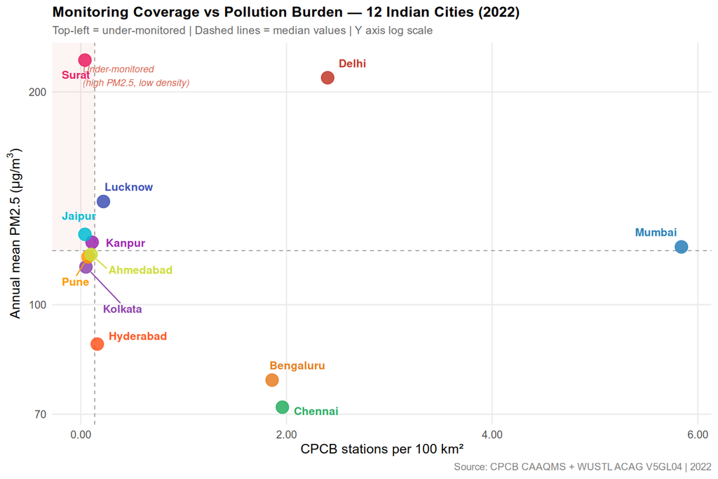

Station density vs annual mean PM2.5 across 12 Indian cities, 2022. Cities in the top-left (high PM2.5, low station density) are the most under-monitored relative to their pollution burden. Y-axis on log scale.

```r
# Classify cities into quadrants for visual guidance
median_pm25    <- median(all_city_summary$annual_ground_pm25, na.rm = TRUE)
median_density <- median(all_city_summary$stations_per_100km2, na.rm = TRUE)

all_city_summary <- all_city_summary %>%
  mutate(
    quadrant = case_when(
      annual_ground_pm25 >= median_pm25 &
        stations_per_100km2 <  median_density ~ "High pollution\nLow coverage",
      annual_ground_pm25 >= median_pm25 &
        stations_per_100km2 >= median_density ~ "High pollution\nGood coverage",
      annual_ground_pm25 <  median_pm25 &
        stations_per_100km2 <  median_density ~ "Low pollution\nLow coverage",
      TRUE                                    ~ "Low pollution\nGood coverage"
    )
  )

ggplot(all_city_summary,
       aes(x = stations_per_100km2, y = annual_ground_pm25, color = city)) +
  # Quadrant shading
  annotate("rect",
           xmin = -Inf, xmax = median_density,
           ymin = median_pm25, ymax = Inf,
           fill = "#d6604d", alpha = 0.06) +
  annotate("text",
           x = median_density * 0.1, y = max(all_city_summary$annual_ground_pm25) * 0.95,
           label = "Under-monitored\n(high PM2.5, low density)",
           size = 3, color = "#d6604d", hjust = 0, fontface = "italic") +
  geom_vline(xintercept = median_density, linetype = "dashed",
             color = "grey60", linewidth = 0.4) +
  geom_hline(yintercept = median_pm25, linetype = "dashed",
             color = "grey60", linewidth = 0.4) +
  geom_point(size = 5, alpha = 0.85) +
  ggrepel::geom_text_repel(
    aes(label = city),
    size          = 3.5,
    fontface      = "bold",
    box.padding   = 0.6,
    point.padding = 0.4,
    show.legend   = FALSE,
    max.overlaps  = 20
  ) +
  scale_color_manual(values = all_colors, guide = "none") +
  scale_x_continuous(labels = scales::number_format(accuracy = 0.01)) +
  scale_y_log10() +
  labs(
    title    = "Monitoring Coverage vs Pollution Burden — 12 Indian Cities (2022)",
    subtitle = "Top-left = under-monitored | Dashed lines = median values | Y axis log scale",
    x        = "CPCB stations per 100 km²",
    y        = expression(paste("Annual mean PM2.5 (", mu, "g/m"^3, ")")),
    caption  = "Source: CPCB CAAQMS + WUSTL ACAG V5GL04 | 2022"
  ) +
  theme_minimal(base_size = 12) +
  theme(
    text             = element_text(family = "Arial"),
    panel.grid.minor = element_blank(),
    plot.title       = element_text(face = "bold", size = 13),
    plot.subtitle    = element_text(size = 10, color = "grey40"),
    plot.caption     = element_text(size = 9, color = "grey50")
  )
```

```r
ggsave(fig_path("fig4_metro_station_density.png"), width = 11, height = 7, dpi = 300)
```

> **Key finding:** Several highly polluted cities fall in the under-monitored quadrant — high PM2.5 but low station density. This is the most concerning combination: cities that need monitoring the most are the least well covered.

# Discussion

## Geography Drives the Seasonal Story

The most striking finding from the seasonal analysis is how strongly geography shapes pollution patterns. Delhi and Kolkata — both on the Indo-Gangetic Plain — show the most pronounced winter peaks. The IGP acts as a natural trap: the Himalayas block cold northern winds from dispersing pollutants, and shallow temperature inversions concentrate emissions near the surface. Coastal cities (Mumbai, Chennai) benefit from sea breezes that provide partial ventilation year-round.

## Monitoring Coverage

The station density analysis reveals that monitoring investment does not always match pollution burden. The 12-city scatter highlights that many large, polluted cities remain significantly under-monitored relative to their pollution burden — the cities that most need measurement are often the least well served.

# Limitations

- **SD ribbons**: The ±1 SD ribbon assumes roughly symmetric distributions. PM2.5 is typically right-skewed — the ribbon’s lower bound can dip below plausible values on clean days. Interpret the ribbon as an indicator of spread, not a strict confidence interval.
- **Satellite data version**: V5GL04 covers 1998–2022. The methodology is identical for any year once V6GL02 is available.
- **Independent heatmap scales**: Per-city colour scales reveal intra-city spatial structure but cannot be used to compare absolute pollution levels across cities. Use Figure 2 for cross-city absolute comparison. Cities are grouped geographically — IGP (Delhi, Kolkata, Kanpur) and coastal/southern (Mumbai, Chennai, Bengaluru) — to aid interpretation.
- **City boundary files**: Results are sensitive to how city boundaries are defined. Administrative boundaries may not correspond to the functional urban area where pollution is generated and measured.
- **Station count only**: This analysis counts stations but does not assess their spatial distribution within each city.
- **2022 only**: A single year may not represent the long-term pollution climatology. Year-to-year variability, particularly in monsoon intensity, can shift annual means significantly.
- **Kolkata boundary**: Combines four GADM districts (Kolkata, North 24 Parganas, South 24 Parganas, Haora) to ensure all 7 CPCB stations fall within the boundary.
- **Hyderabad boundary**: Combines Hyderabad and Ranga Reddy GADM districts (~8,500 km²). The Hyderabad district alone (~197 km²) reflects older administrative boundaries that predate the GHMC expansion.